# Busca na Wikimedia

##### Gabriel Joseph Ramos Rafael

```r
    library(tidyverse)
library(here)
library(lubridate)
theme_set(theme_bw())
```

```r
buscas = read_csv(here::here("data/search_data.csv"))
```

### Qual a média de clickthrough rate diária? Como ela varia entre os grupos?

Nesta visualização buscamos representar através de pontos, a variação dos dados clickthrough rate, os valores são conectados por segmentos de reta, visando orientar o angulo dessa mudança.

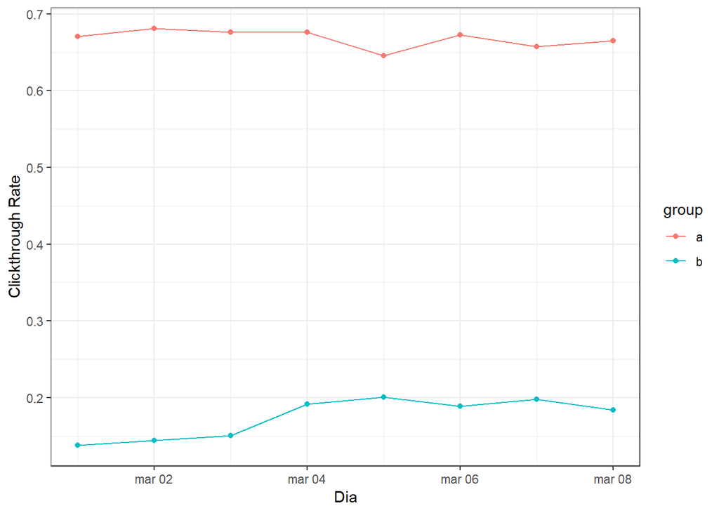

```r
clickthrough <- buscas %>% group_by(day = date(session_start_date),session = session_id, group) %>%
    summarise(clicks = sum(num_clicks)) %>%
    group_by(day, group) %>%
    summarise(clickthrough_rate = sum(clicks > 0)/n())

clickthrough %>%
 ggplot(aes(x = day, y = clickthrough_rate, color = group, group = group))+
  geom_point(stat = "identity") +geom_line() +
  xlab("Dia") +
  ylab("Clickthrough Rate")
```

### Qual a posição dos links que as pessoas tendem a clicar primeiro? Como essa tendência varia diariamente?

Nesta visualização mostra-se a variação dos links clicados em relação ao dia da semana, podemos observar que para o grupo B a média dos links clicados é a mesma, diferente do grupo A, que possui uma variação mais representativa.

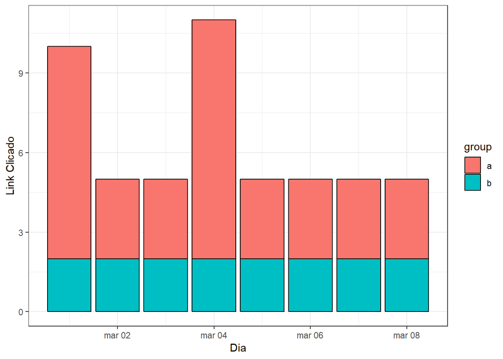

```r
try_results <- buscas %>% group_by(day = date(session_start_date)) %>%
    group_by(day, group) %>%
    summarise(try_results = round(mean(na.exclude(first_click))))

try_results %>%
    ggplot(aes(x = day, y = try_results, fill = group))+
    geom_bar(colour="black", stat="identity") +
    xlab("Dia") +
    ylab("Link Clicado")
```

O termo “Link Clicado” que aparece no eixo y do gráfico representa a posição do link na listagem de resultados da busca.

### Qual a média de zero results rate diária? Como ela varia entre os grupos?

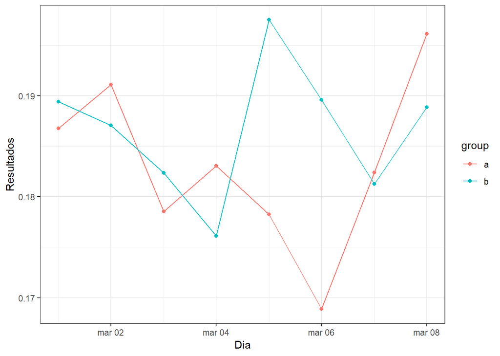

```r
zero_results <- buscas %>% group_by(day = date(session_start_date)) %>%
    group_by(day, group) %>%
    summarise(zero_results = sum(results == 0)/n())


zero_results %>%
 ggplot(aes(x = day, y = zero_results, color = group, group = group))+
  geom_point(stat = "identity") +geom_line() +
  xlab("Dia") +
  ylab("Resultados")
```

### Qual a relação entre o tamanho da sessão e a quantidade de buscas realizada na mesma?

Tentando mostrar um aspecto de dispersão dos dados, nesse gráfico buscamos observar como o tamanho da sessão influencia na quantidade de “queries” realizadas pelo usuário em sua busca.

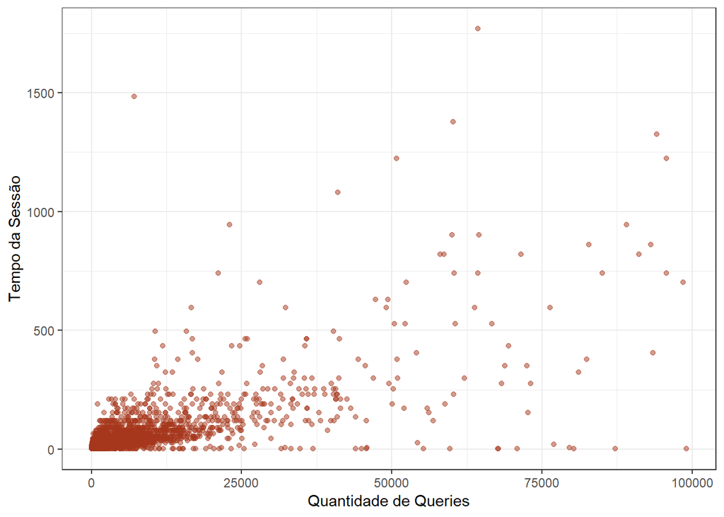

```r
session_size <- buscas %>% group_by(session = session_id) %>%
    summarise(size = sum(session_length), index = sum(search_index)) %>%
    group_by(session, size, index) %>%
    filter(size < 100000 )

session_size %>%
  ggplot(aes(x = size, y = index)) +
  geom_point(alpha = .5, color = "#a6371c")+
  xlab("Quantidade de Queries") +
  ylab("Tempo da Sessão")
```